# Advanced R - data.table

Ali Ehlen

2018-09-19

# a few introductory points

## what is `data.table`?

- “`data.table` is an R package that provides an enhanced version of data.frames”
- “Briefly, if you are interested in reducing programming and compute time tremendously, then this package is for you.”
- - [authors of `data.table`](https://cran.r-project.org/web/packages/data.table/vignettes/datatable-intro.html)
- `data.tables` provide an alternate framework for tabular data analysis, similar to `dplyr`

## why do we care?

- `data.table` is popular

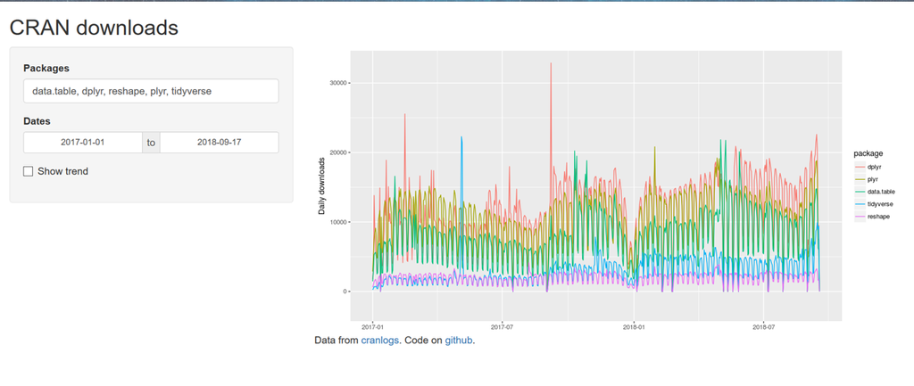

- `data.table` performs better on large data sets
- you might prefer the syntax and/or philosophy behind it

# basic use of `data.table`

## read in data

```r
# import data.table library
library(data.table)
library(lubridate)

data_file <- here::here("data", "generation.csv")

# read in two versions of data, one as a data.frame and one as a data.table
generation_df <- read.csv(data_file, stringsAsFactors = F)

generation_dt <- fread(data_file)
```

We’ll get into `fread` later, but know for now that it is approximately equivalent to `read.csv`, but produces a `data.table` instead of a `data.frame`.

First things first: a `data.table` is an object that is very similar to a `data.frame`. In fact, it inherits from a `data.frame`.

```r
View(generation_df)
View(generation_dt)

generation_df
generation_dt

class(generation_df) # "data.frame"
class(generation_dt) # "data.table" "data.frame"

str(generation_df)
str(generation_dt)
```

There are some major differences between the two:

- the `data.table` package was developed with a fundamentally different philosophy than `dplyr` was, which results in syntax sometimes looking very different
- `data.table` syntax and other built-in features have been optimized for speed and performace, so often less time and memory is required to perform the same operations, in particular on large and complex data sets
- many of the features we’ve talked about come with `data.table`, so you need to load fewer packages

However, since a `data.table` object is still also a `data.frame`, the two are still very much related. For example, a `data.table` can be passed to any function that expects a `data.frame` and this shouldn’t break anything. The major differences arise when a user is interacting with a `data.table`, as well as with the additional features built in to the package.

The `data.table` package is powerful, fairly complex, and has many more features than we will talk about today. Links to useful resources are at the end of the lecture notes for anyone interested in learning more about what is possible with `data.table`.

## basics of slicing, column operations, and group by

While `dplyr` syntax is heavily dependent on the concept of verbs, `data.table` syntax is based on a consistent set of rules for interpreting input in brackets.

This set of rules can be most easily summarized as:

`dt[i, j, by]`

where `i` is an expression that filters rows, `j` is a flexible and powerful expression pertaining to column operations, and `by` enables grouping by variables. Let’s build this up, starting with column selection.

```r
# data.frame
generation_df[,"small_hydro"]
select(generation_df, small_hydro)

# data.table
generation_dt[,small_hydro]
```

Notice that there are no quotes around the column name in the `data.table` version. This is because within the `data.table` brackets, in this `j` portion after the first comma, column names can be used as variable names. This will have major implications soon. We can also pull out multiple columns:

```r
# data.frame
select(generation_df, datetime, small_hydro)

# data.table
generation_dt[,.(datetime, small_hydro)]
```

Note that I had to surround the multiple column names in `.()`, which, in `data.table`, is shorthand for `list()`. Also note that surrounding an expression in `j` with a `list()` command causes the output to be a new `data.table`: while `generation_dt[,small_hydro]` returned a numeric vector, `generation_dt[,.(small_hydro)]` output a one-column `data.table`. We can always add in a filter by rows here. Say we only wanted to look at small_hydro generation when solar output is zero:

```r
# data.table
generation_dt[solar == 0,.(datetime, small_hydro)]
```

Just add the desired filter, treating column names as variables, to the `i` expression before the first comma. Note that this nicely avoids the necessity in base R of having to repeatedly type in the name of the data.frame. We can write `generation_dt[solar == 0]` instead of `generation_dt[generation_dt$solar == 0]`.

Recall that we mentioned that the `j` expression (after the first comma) is a column operation. That means that I can perform operations on these columns right in the `data.table` brackets, using the column name variables available to me. Let’s say we want the total amount of hydro power in every hour:

```r
# data.table
generation_dt[,small_hydro + large_hydro]
```

I can return these all as a data.table, and even name those columns:

```r
# data.table
generation_dt[,.(datetime, small_hydro, large_hydro, all_hydro = small_hydro + large_hydro)]
```

I can also use a special `data.table` symbol, `:=`. Just like `.()` means “return another `data.table`”, `:=` means “modify a column in place, by reference”. R has an issue (though I think this has somewhat imrpoved over time) of making copies of whole or large parts of objects, even when you’re trying to modify only a small part of that obejct. This is fine for small objects, but not great when you’re working with a set of data that is pushing the limits of memory on your machine. This function (and several others implemented in `data.table`) improve on this and this is an important piece of `data.table`’s efficiency gains.

Say we wanted to create a column called `all_hydro` in the original `data.table`:

```r
# data.table
generation_dt[,all_hydro := small_hydro + large_hydro]
```

This operation is one of the many that helps give `data.table` its speed and performance boost. This is, of course, in contrast to the base R `generation_dt["all_hydro"] <- generation_dt["small_hydro"] + generation_dt["large_hydro"]`

The last of the bracket structure we haven’t covered is the `by`, which comes after the second comma. That is a special spot for any sort of `groupby` functionality you might need. Let’s say I wanted to see how much energy is generated by hydro plants when the output of solar plants is zero. I can do this a couple of ways.

```r
# two steps
generation_dt[solar > 0, solar_on := TRUE]
generation_dt[is.na(solar_on), solar_on := FALSE]

# more compact
generation_dt[,solar_on := ifelse(solar > 0, TRUE, FALSE)]
```

Now, I have a variable I can group by:

```r
generation_dt[,sum(all_hydro), by = solar_on]
```

Note that the `by` section also can handle functions. So, we could really have done this all in one line:

```r
generation_dt[,sum(all_hydro), by = solar > 0]
```

We could also put multiple columns in the `by` section:

```r
generation_dt[,sum(all_hydro), by = .(solar > 0, wind > 0)]
```

> *Exercise:* Using `data.table`’s special operator and what you learned about converting datetimes in the previous session, convert the `datetime` column to a POSIX object. Then, create a new `data.table` that contains the total renewable energy generation (solar + wind) by hour and day. You will probably need lubridate’s functions `day()` and `hour()`

> *Answer:*

> ```r
> generation_dt[, datetime := as_datetime(datetime)]
>
> generation_dt[,.(solar_wind = solar + wind), by = .(day(datetime), hour(datetime))]
> ```

Columns can also be removed using `NULL`, similarly to base R:

```r
generation_dt[,solar_on := NULL]
generation_dt[,all_hydro := NULL]
```

`data.table` has a few other bonus features, but what we’ve just covered here is a small set of rules that can combine in flexible and powerful ways to enable a huge amount of analysis.

# `data.table` upgrades to other functions

Though we’ve just covered most of the basic `data.table` syntax, there is other functionality that comes with the package. For example, we’ve seen these functions in other contexts:

- `melt`
- `dcast`
- `merge`
- `order`

Since a `data.table` is still also a `data.frame`, a `data.table` can be pased to any of these and nothing bad will happen. However, the authors of `data.table` did one better. They implemented a special `data.table` version of (at least) these functions. These generally work with syntax that is identical to the originals’, but the `data.table` versions have a faster implementation and some advanced features. They are called by simply passing a `data.table` to one of the original functions. For example, `merge(dt1, dt2, ...)` will call `merge.data.table`. We won’t get into the advanced features now, but that information is in the help files for these functions or online (see resources at end of this file).

*Note:* sometimes loading `reshape` or `dplyr` will disrupt this behavior and the original functions will be dispatched. To get around this, either call `merge.data.table` directly or don’t load those packages.

To demonstrate, we can read in `imports.csv`, as you did this morning, and merge it with `generation_dt`, then melt it, just as before.

```r
imports <- fread(here::here("data", "imports.csv"))
imports[,datetime := as_datetime(datetime)]

all_generation <- merge(generation_dt, imports, by = "datetime")

all_generation_long <-  melt(all_generation,
                             id.vars = "datetime",
                             variable.name = "type")
```

As Richard pointed out this morning, data in long format is “tidier” and generally (though not in every case) easier to deal with. Now, we can easily find, for example, the average of each generation type by hour.

```r
hourly_generation <- all_generation_long[,.(generation = mean(value)),
                                         by = .(hour(datetime), type)]

# check to see if this makes sense
hourly_generation[type == "solar"]
```

> *Exercise:* Convert this `dplyr` syntax into `data.table` syntax (remember that this created the columns `day`, `log_output`, and `per_output`)

> ```r
> long_ca_energy <- long_ca_energy %>%
>  mutate(day = as_date(datetime),
>         log_output = log(output)) %>%
>  group_by(day) %>%
>  mutate(total_daily_output = sum(output, na.rm = T)) %>%
>  ungroup() %>%
>  mutate(per_output = output/total_daily_output)
> ```

> *Answer:*

> ```r
> all_generation_long[,day := as_date(datetime)]
> all_generation_long[,log_output := log(value)]
> all_generation_long[,per_output := value/sum(value), by = day]
> ```

> Note that this is possible to do in one command:

> ```r
> all_generation_long[,c("day2", "log_output2", "per_output2") := .(as_date(datetime), log(value), value/sum(value)), by = day]
> # or
> all_generation_long[,`:=`(day2 = as_date(datetime),
>                          log_output2 = log(value),
>                          per_output2 = value/sum(value)),
>                    by = day]
>
> # can check this this resulted in correct values
> all_generation_long[,all(day == day2)]
> all_generation_long[,all(per_output2 == per_output)]
> ```

> but how you prefer to write this depends on you. The first seems less readable to me, but there are certainly some cases in which this syntax might make sense.